# Beer Analysis

Bodie Franklin

3/7/2020

## Project Description

### (ABV), International Bitterness Units (IBU) and the Style # of each craft beer.

```r
defaultW <- getOption("warn")
options(warn = -1)

library(tidyverse)
library(ggplot2)
library(stringr)
library(dplyr)
library(caret)
library(class)
breweries = read.csv(file= "C:/Users/bodie/Documents/Breweries.csv",header = TRUE)
beer = read.csv(file= "C:/Users/bodie/Documents/Beers.csv",header = TRUE)
```

#### Question #1

#### Graph to show how many breweries per state

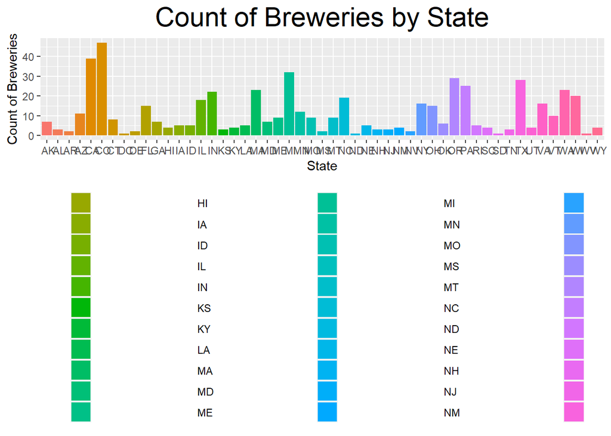

```r
breweries %>% ggplot(aes(x = State,fill=State )) +
  geom_bar(stat = "count") +
  ggtitle("Count of Breweries by State") + ylab("Count of Breweries")+theme(legend.position = "bottom",legend.spacing.x = unit(3.0, 'cm'))+
  theme(plot.title = element_text(hjust = 0.5))+ theme(plot.title = element_text(size=22))
```

```r
brewbeer <- merge(beer,breweries,by.x="Brewery_id", by.y = "Brew_ID")

head(brewbeer,6)
```

```
##   Brewery_id        Name.x Beer_ID   ABV IBU
## 1          1  Get Together    2692 0.045  50
## 2          1 Maggie's Leap    2691 0.049  26
## 3          1    Wall's End    2690 0.048  19
## 4          1       Pumpion    2689 0.060  38
## 5          1    Stronghold    2688 0.060  25
## 6          1   Parapet ESB    2687 0.056  47
##                                 Style Ounces             Name.y        City
## 1                        American IPA     16 NorthGate Brewing  Minneapolis
## 2                  Milk / Sweet Stout     16 NorthGate Brewing  Minneapolis
## 3                   English Brown Ale     16 NorthGate Brewing  Minneapolis
## 4                         Pumpkin Ale     16 NorthGate Brewing  Minneapolis
## 5                     American Porter     16 NorthGate Brewing  Minneapolis
## 6 Extra Special / Strong Bitter (ESB)     16 NorthGate Brewing  Minneapolis
##   State
## 1    MN
## 2    MN
## 3    MN
## 4    MN
## 5    MN
## 6    MN
```

```r
tail(brewbeer,6)
```

```
##      Brewery_id                    Name.x Beer_ID   ABV IBU
## 2405        556             Pilsner Ukiah      98 0.055  NA
## 2406        557  Heinnieweisse Weissebier      52 0.049  NA
## 2407        557           Snapperhead IPA      51 0.068  NA
## 2408        557         Moo Thunder Stout      50 0.049  NA
## 2409        557         Porkslap Pale Ale      49 0.043  NA
## 2410        558 Urban Wilderness Pale Ale      30 0.049  NA
##                        Style Ounces                        Name.y          City
## 2405         German Pilsener     12         Ukiah Brewing Company         Ukiah
## 2406              Hefeweizen     12       Butternuts Beer and Ale Garrattsville
## 2407            American IPA     12       Butternuts Beer and Ale Garrattsville
## 2408      Milk / Sweet Stout     12       Butternuts Beer and Ale Garrattsville
## 2409 American Pale Ale (APA)     12       Butternuts Beer and Ale Garrattsville
## 2410        English Pale Ale     12 Sleeping Lady Brewing Company     Anchorage
##      State
## 2405    CA
## 2406    NY
## 2407    NY
## 2408    NY
## 2409    NY
## 2410    AK
```

### Question #3

### This will impute values for missing IBU Values

### This was done by calculating and averaging the Alpha Acid * Boil Time by Beer Style

### and imputing IBU Values based on this average

```r
IBUTrain = filter(beer,(!is.na(beer$IBU)))

IBUTrain$AABT  <-  (IBUTrain$IBU*7.25)/IBUTrain$Ounces

###this gives us mean AABT by style
AABTMEAN <-IBUTrain %>% group_by(Style) %>% summarise( meanAABT = mean(AABT))
#merge the blank with AABT avgs table by style
Beerwithaabt  <-merge(beer,AABTMEAN,by="Style",all.x=TRUE)

##calculate the IBU based off style avg of AABT

Beerwithaabt$AVG_IBU <- (Beerwithaabt$Ounces*Beerwithaabt$meanAABT)/7.25
```

##### The following will calculate an average ABV by Style

##### to use for missing values.

```r
##  Adjust  null ABV Values
ABVTrain = filter(beer,(!is.na(beer$ABV)))
ABVbyStyle <- as.data.frame(ABVTrain %>% group_by(Style) %>% summarise(meanABV = mean(ABV)))
beerwavgs <- merge(Beerwithaabt,ABVbyStyle, by = "Style",all.x = TRUE)
```

#### Add in the Derived ABV and IBU values and omit any

#### rows where IBU could not be calculated because there

#### was no training data. In other words, there

#### were no rows with valid IBU data for that particular

#### style of beer

```r
##  Calculate drvIBU and drvABV fields in final Beer dataset so that we have a value for ABV and IBU to use for all rows
beerfnl1 <- mutate(beerwavgs,drvIBU=ifelse(is.na(IBU),AVG_IBU,IBU))
beerfnl <- mutate(beerfnl1,drvABV=ifelse(is.na(ABV),meanABV,ABV))

#omit remaining null averaged IBU because there was no data to train on.  Mostly Cider
beerfnl2 <- filter(beerfnl,!is.na(drvIBU))
```

### Merge with Breweries. Get rid of Missing Style.

```r
brewdata <- filter(merge(beerfnl2,breweries,by.x="Brewery_id", by.y = "Brew_ID"),!is.na(Style))
```

#### Question 4, 5 6 and 7

#### Graphs to show ABV and IBU by state and

#### relationships between ABV and IBU

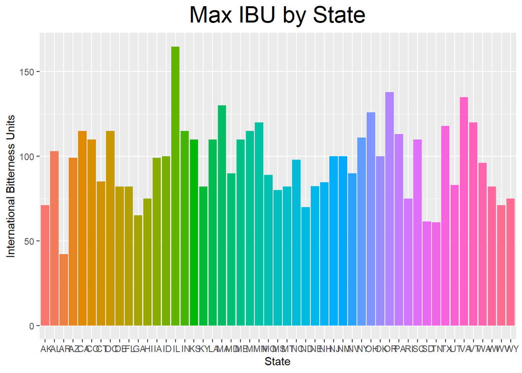

```r
### Compute the median alcohol content and international bitterness unit for each state. Plot a bar chart to compare.
brewdata2 <- as.data.frame(brewdata %>% group_by(State) %>% summarise(medibu = median(drvIBU)))
brewdata3 <- as.data.frame(brewdata %>% group_by(State) %>% summarise(medabv = median(drvABV)))
brewdata4 <- merge(brewdata2,brewdata3,by="State",all.x=TRUE)

maxibu <- as.data.frame(brewdata %>% group_by(State) %>% summarise(maxibu = max(drvIBU), maxabv = max(drvABV)))
maxibu %>% ggplot(aes(x = State, y = maxibu, fill=State)) +
  geom_bar(stat = "identity", ) +
  ggtitle("Max IBU by State") +
  xlab ("State") +
  ylab ("International Bitterness Units") +
  theme(legend.position="none")+
  theme(plot.title = element_text(hjust = 0.5))+ theme(plot.title = element_text(size=22))
```

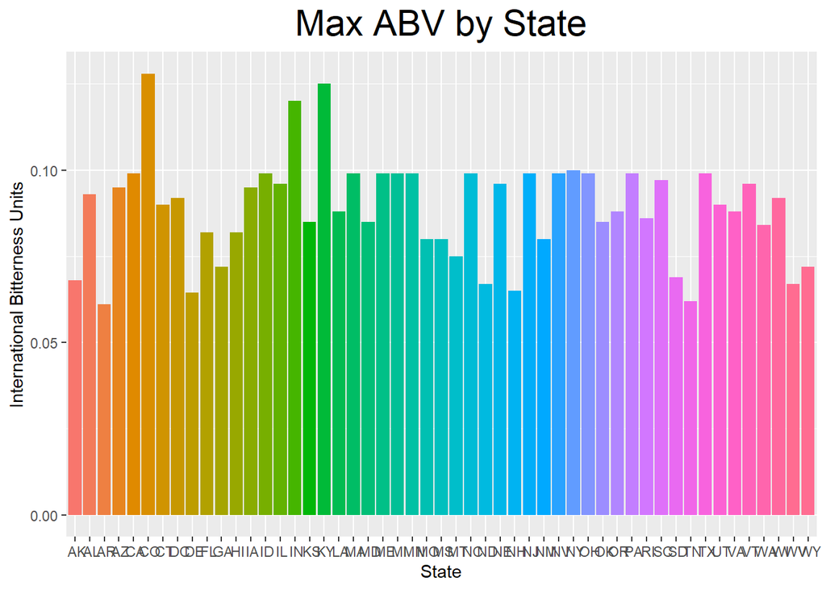

```r
maxibu %>% ggplot(aes(x = State, y = maxabv, fill=State)) +
  geom_bar(stat = "identity", ) +
  ggtitle("Max ABV by State") +
  xlab ("State") +
  ylab ("International Bitterness Units") +
  theme(legend.position="none")+
  theme(plot.title = element_text(hjust = 0.5))+ theme(plot.title = element_text(size=22))
```

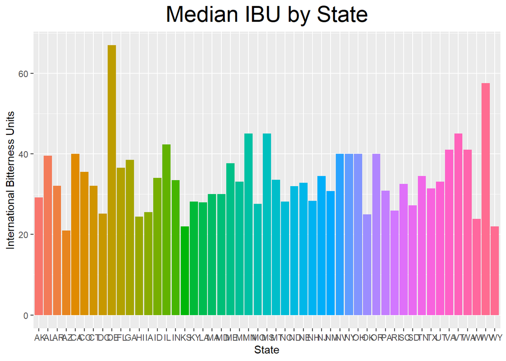

```r
brewdata4 %>% ggplot(aes(x = State, y = medibu, fill=State)) +
  geom_bar(stat = "identity", ) +
  ggtitle("Median IBU by State") +
  xlab ("State") +
  ylab ("International Bitterness Units") +
  theme(legend.position="none")+
  theme(plot.title = element_text(hjust = 0.5))+ theme(plot.title = element_text(size=22))
```

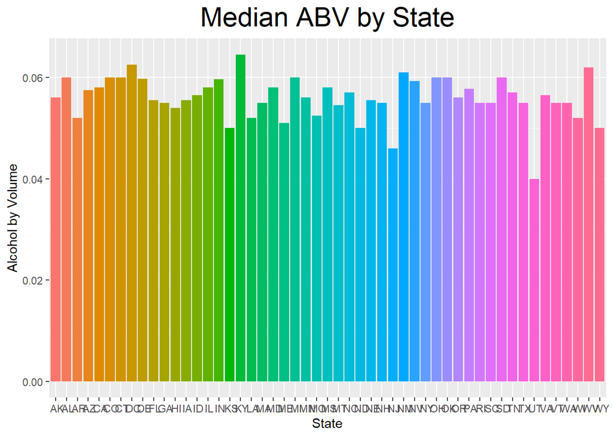

```r
brewdata4 %>% ggplot(aes(x = State, y = medabv, fill=State)) +
    geom_bar(stat = "identity", ) +
    ggtitle("Median ABV by State") +
    xlab ("State") +
    ylab ("Alcohol by Volume") +
    theme(legend.position="none")+
  theme(plot.title = element_text(hjust = 0.5))+ theme(plot.title = element_text(size=22))
```

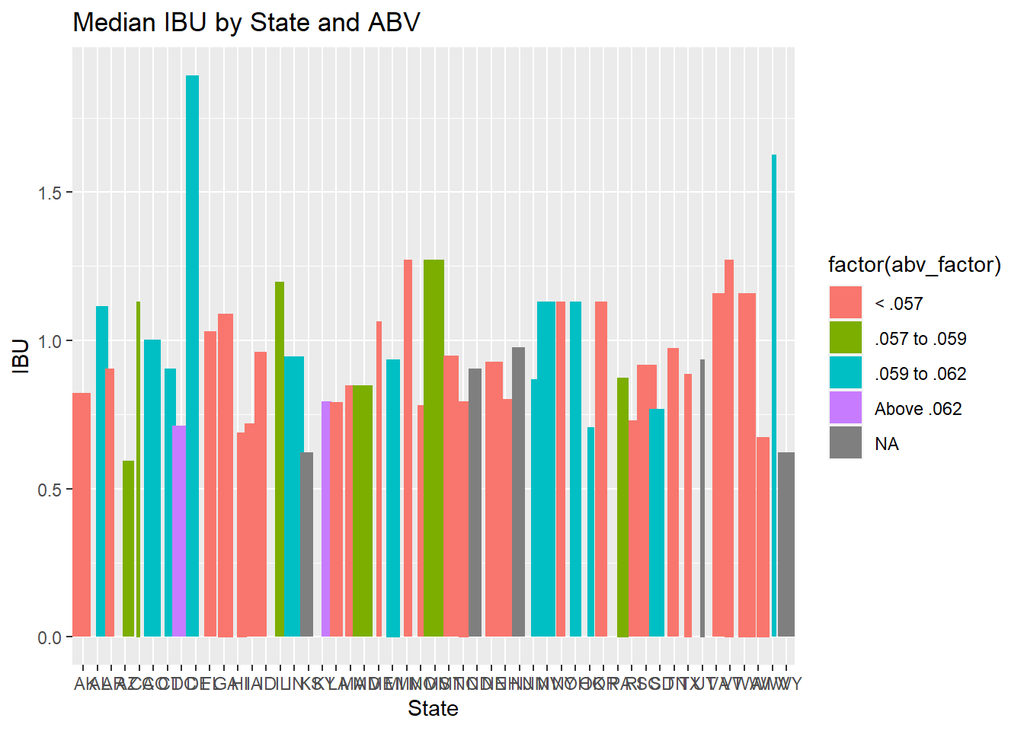

```r
####  Scaled IBU and ABV - not really used #####

brewdata4$scaledibu = scale(brewdata4$medibu,center=FALSE, scale=TRUE)
brewdata4$scaledabv = scale(brewdata4$medabv,center=FALSE, scale=TRUE)

### Make ABV Factors to graph ABV and IBU on same plot

brewdata4$abv_factor = cut(brewdata4$medabv, breaks = c(.05,.057,.059,.062,.069), labels = c("< .057",".057 to .059", ".059 to .062","Above .062"))

brewdata4 %>% ggplot(aes(x = State, y = scaledibu, fill=factor(abv_factor))) +
    geom_bar(stat = "identity",position="jitter" ) +
    ggtitle("Median IBU by State and ABV") +
    xlab ("State") +
    ylab ("IBU")
```

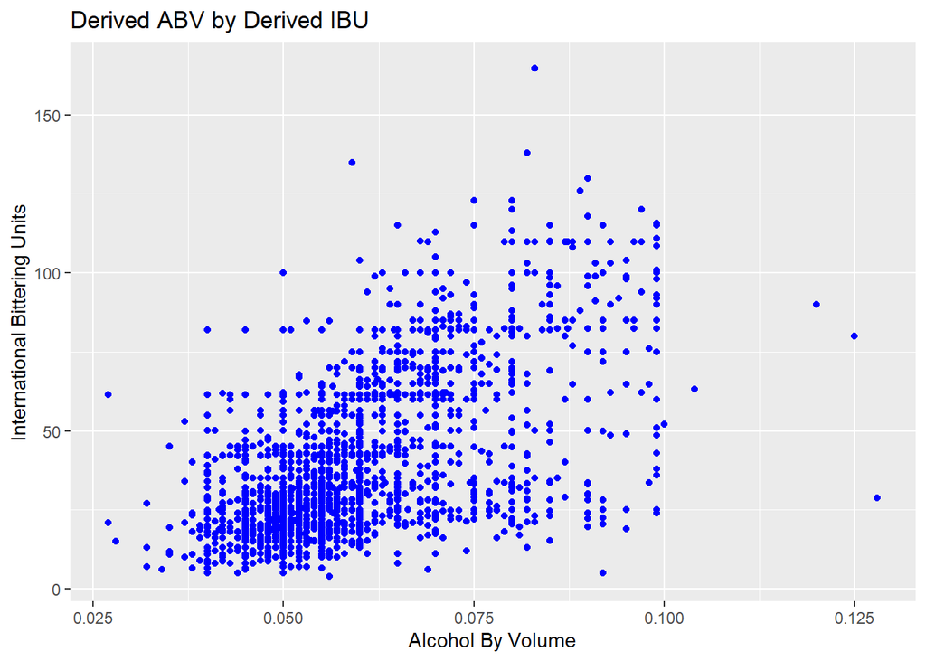

```r
brewdata %>%  ggplot(mapping = aes(x = drvABV, y = drvIBU)) +
     geom_point(position = "jitter",col="Blue") +
     ggtitle("Derived ABV by Derived IBU") +
    xlab ("Alcohol By Volume") +
    ylab ("International Bittering Units")
```

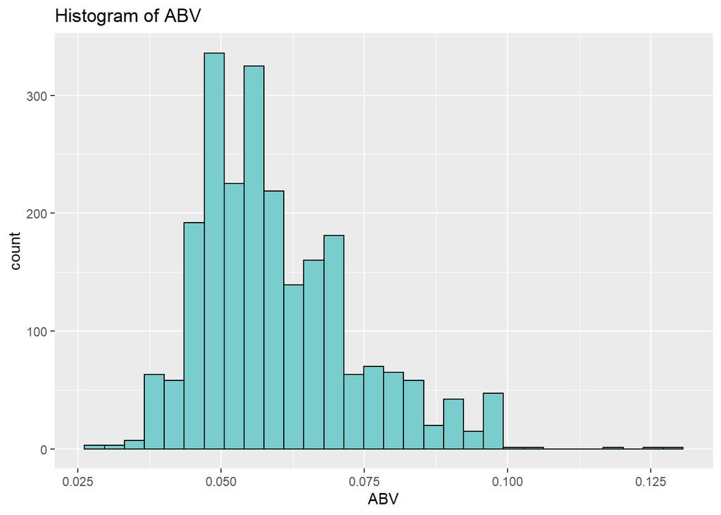

```r
brewdata %>%  ggplot(aes(x = ABV)) + geom_histogram(color='black',fill='darkslategray3') + ggtitle("Histogram of ABV")
```

##### Question 8

##### Create a varaible named Typed. Narrow our analysis to IPA and ALE. We will be creating a reduced dataset called “final” for this analysis

### The point of this exercise is to show that stat difference exist between IPA and ALe, so we can use KNN to classify a beer as Ale or IPA. We have confidence in KNN because of the results of the confusionmatrix.

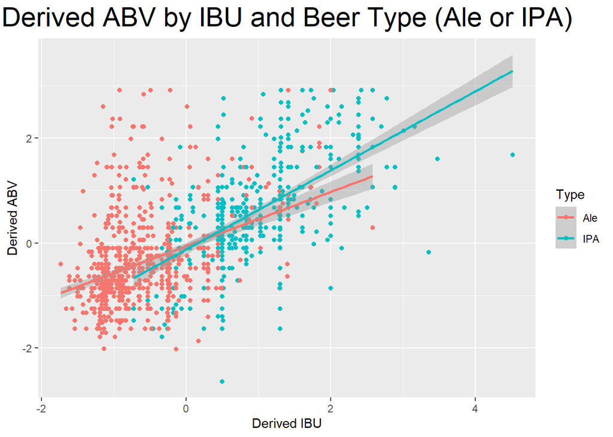

```r
final <-brewdata %>% filter(grepl("IPA|India Pale Ale|\\bAle\\b",brewdata$Style))
final$TYPE <-ifelse(str_detect(final$Style,"IPA|India Pale Ale"),"IPA","Ale")
final$TYPE <-as.factor(final$TYPE)

#cleaning up dataframe
final<-data.frame(Brewery_id =final$Brewery_id, Beer_name = final$Name.x, Beer_ID = final$Beer_ID, Ounces = final$Ounces, drvIBU = final$drvIBU,
                  drvABV = final$drvABV, Brewery_name = final$Name.y, City = final$City, State = final$State, Style = final$Style, Type = final$TYPE)
final <-na.omit(final)
#graph of Type of Beers..IPA VS ALE
final %>% ggplot(mapping =aes (x= scale(drvIBU), y= scale(drvABV),col= Type)) +
  geom_point(position='jitter') +
  ggtitle("Derived ABV by IBU and Beer Type (Ale or IPA)") +
  xlab ("Derived IBU") +
  ylab ("Derived ABV") +
  geom_smooth(method='lm')+
  theme(plot.title = element_text(hjust = 0.5))+ theme(plot.title = element_text(size=22))
```

```r
# Create Train and Test set for KNN in order to classify beer as IPA or ALE

splitPerc = .7
trainfinal = sample(1:dim(final)[1],round(splitPerc * dim(final)[1]))
train = final[trainfinal,]
test = final[-trainfinal,]


classifications = knn(train[,c(5,6)],test[,c(5,6)],train$Type,prob = TRUE, k =20)
confusionMatrix(test$Type,classifications)
```

```
## Confusion Matrix and Statistics
##
##           Reference
## Prediction Ale IPA
##        Ale 252  35
##        IPA  20 153
##
##                Accuracy : 0.8804
##                  95% CI : (0.8472, 0.9086)
##     No Information Rate : 0.5913
##     P-Value [Acc > NIR] : < 2e-16
##
##                   Kappa : 0.7495
##
##  Mcnemar's Test P-Value : 0.05906
##
##             Sensitivity : 0.9265
##             Specificity : 0.8138
##          Pos Pred Value : 0.8780
##          Neg Pred Value : 0.8844
##              Prevalence : 0.5913
##          Detection Rate : 0.5478
##    Detection Prevalence : 0.6239
##       Balanced Accuracy : 0.8702
##
##        'Positive' Class : Ale
##
```

```r
#filter out the data in order to perform Ttest on the Ale & IPA mean to show they are different. The results of the ttest show IPA & ABV have different profiles for IBV & ABV
#this gives us more confidence in using KNN to classify a beer as ALE or IPA because there is a stat difference between the beers.
Ale <- final %>% filter(Type == "Ale")
IPA <- final %>% filter(Type =="IPA")

t.test(x=Ale$drvIBU,y=IPA$drvIBU)
```

```
##
##  Welch Two Sample t-test
##
## data:  Ale$drvIBU and IPA$drvIBU
## t = -39.398, df = 1081.7, p-value < 2.2e-16
## alternative hypothesis: true difference in means is not equal to 0
## 95 percent confidence interval:
##  -40.26259 -36.44243
## sample estimates:
## mean of x mean of y
##  34.30096  72.65347
```

```r
t.test(x=Ale$drvABV,y=IPA$drvABV)
```

```
##
##  Welch Two Sample t-test
##
## data:  Ale$drvABV and IPA$drvABV
## t = -19.151, df = 1099.8, p-value < 2.2e-16
## alternative hypothesis: true difference in means is not equal to 0
## 95 percent confidence interval:
##  -0.01327464 -0.01080731
## sample estimates:
##  mean of x  mean of y
## 0.05675783 0.06879880
```

##Question 9. Since there more Ale beers within the dataset, we believe that consumers have a higher demand for Ale beer than an IPA. Perhaps majority of consumers consider IPA to be to bitter. We have identified the Ale beer market as an area to enter. Budweiser should create an Ale beer with the median ABV and IBU profile of Ale beer. They should only enter states that have ale breweries between 26 and 12. This range provides them the opportunity to gain a market share of a growing taste preference for Ale Beer. If Budweiser enter a state outside of this range, then they may not be competitive due to oversaturated or lack of interest from consumers. Further analysis of state to state migration needs to be done for states with lower number of breweries. If consumers are migrating from a “Ale State” , then they would be increasing the Ale taste preference within the state. Since the craft beer movement is entering the mature phase of the business cycle, we have reason to believe low brewery states do not have the consumer base to support Ale beer consumption.

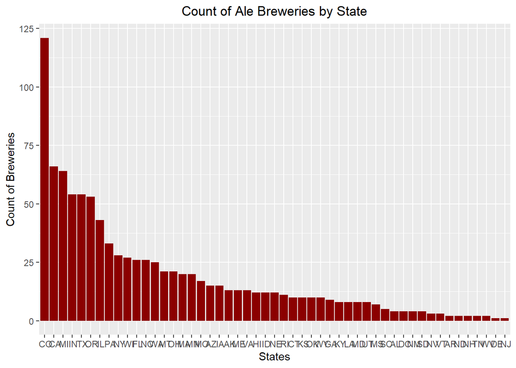

```r
#overall summary of Ale vs Beer


#graph of Ale breweries in USA

Aledata = Ale %>%  group_by(State) %>% summarise(counts = n())
Aledata %>%ggplot(aes(x =reorder(State, -counts), y = counts)) +geom_bar(stat = "identity",fill="darkred")+ggtitle("Count of Ale Breweries by State") + ylab("Count of Breweries")+xlab("States")+
  theme(plot.title = element_text(hjust = 0.5))
```